# Praca domowa 1

## Zbiór danych

Nazwa: heart_disease

Źródło: https://www.mldata.io/dataset-details/heart_disease/

## Opis zbioru

The original database containes 76 attributes and information from 4 different hospitals. This subset of dataset is the most widely used and contains 14 attributes and only information from the Cleveland hospital.

age - age of patient

sex - 1=male; 0=female

cp - chest pain type: 1=typical angina; 2=atypical angine; 3=non-anginal pain; 4=asymptomatic

trestbps - resting blood pressure (mm Hg)

chol - serum cholestrol (mg/dl)

fbs - fasting blood sugar: 1 if > 120 mg/dl; 0 otherwise

restecg - resting electrocardiographic results: 0=normal; 1=having ST-T wave abnormality; 2=showing probable or definite left ventricular hypertrophy

thalach - maximum heart rate achieved

exang - exercise induced angina: 1=yes; 0=no

oldpeak - ST depression induced by exercise relative to rest

slope - the slope of the peak exercise ST segment: 1=upsloping; 2=flat; 3=downsloping

ca - number of major vessels (0-3) colored by flourosopy

thal - 3=normal; 6=fixed defect; 7=reversable defect

num - predicted attribute; 0=HEART DISEASE; 1=NO HEART DISEASE

## Wczytanie pakietów

```python
import pandas as pd
import numpy as np
import seaborn as sns
import matplotlib.pyplot as plt
from pandas_profiling import ProfileReport
```

## Wczytanie danych

```python
data=pd.read_csv('heart_disease_dataset.csv')
data
```

|  | age | sex | cp | trestbps | chol | fbs | restecg | thalach | exang | oldpeak | slope | ca | thal | num |
| --- | --- | --- | --- | --- | --- | --- | --- | --- | --- | --- | --- | --- | --- | --- |
| 0 | 63 | 1 | 1 | 145 | 233 | 1 | 2 | 150 | 0 | 2.3 | 3 | 0 | 6 | 0 |
| 1 | 67 | 1 | 4 | 160 | 286 | 0 | 2 | 108 | 1 | 1.5 | 2 | 3 | 3 | 1 |
| 2 | 67 | 1 | 4 | 120 | 229 | 0 | 2 | 129 | 1 | 2.6 | 2 | 2 | 7 | 1 |
| 3 | 37 | 1 | 3 | 130 | 250 | 0 | 0 | 187 | 0 | 3.5 | 3 | 0 | 3 | 0 |
| 4 | 41 | 0 | 2 | 130 | 204 | 0 | 2 | 172 | 0 | 1.4 | 1 | 0 | 3 | 0 |
| ... | ... | ... | ... | ... | ... | ... | ... | ... | ... | ... | ... | ... | ... | ... |
| 298 | 45 | 1 | 1 | 110 | 264 | 0 | 0 | 132 | 0 | 1.2 | 2 | 0 | 7 | 1 |
| 299 | 68 | 1 | 4 | 144 | 193 | 1 | 0 | 141 | 0 | 3.4 | 2 | 2 | 7 | 1 |
| 300 | 57 | 1 | 4 | 130 | 131 | 0 | 0 | 115 | 1 | 1.2 | 2 | 1 | 7 | 1 |
| 301 | 57 | 0 | 2 | 130 | 236 | 0 | 2 | 174 | 0 | 0.0 | 2 | 1 | 3 | 1 |
| 302 | 38 | 1 | 3 | 138 | 175 | 0 | 0 | 173 | 0 | 0.0 | 1 | -100000 | 3 | 0 |

303 rows × 14 columns

## Typy zmiennych i braki danych

```python
data.info()
```

```
<class 'pandas.core.frame.DataFrame'>
RangeIndex: 303 entries, 0 to 302
Data columns (total 14 columns):
age         303 non-null int64
sex         303 non-null int64
cp          303 non-null int64
trestbps    303 non-null int64
chol        303 non-null int64
fbs         303 non-null int64
restecg     303 non-null int64
thalach     303 non-null int64
exang       303 non-null int64
oldpeak     303 non-null float64
slope       303 non-null int64
ca          303 non-null int64
thal        303 non-null int64
num         303 non-null int64
dtypes: float64(1), int64(13)
memory usage: 33.3 KB
```

#### Komentarz

Dane obejmują 303 pacjentów, zmienne są wyłącznie typów int/float i nie występują braki informacji (prawie, jak się zaraz okaże).

## Czyszczenie danych

```python
# niektore wiersze zawieraja bledne wartosci atrybutu ca (jest to zmienna kategoryczna przyjmujaca wartosci 0, 1, 2 i 3)
data.loc[~data.ca.isin([0, 1, 2, 3]), :]
```

|  | age | sex | cp | trestbps | chol | fbs | restecg | thalach | exang | oldpeak | slope | ca | thal | num |
| --- | --- | --- | --- | --- | --- | --- | --- | --- | --- | --- | --- | --- | --- | --- |
| 166 | 52 | 1 | 3 | 138 | 223 | 0 | 0 | 169 | 0 | 0.0 | 1 | -100000 | 3 | 0 |
| 192 | 43 | 1 | 4 | 132 | 247 | 1 | 2 | 143 | 1 | 0.1 | 2 | -100000 | 7 | 1 |
| 287 | 58 | 1 | 2 | 125 | 220 | 0 | 0 | 144 | 0 | 0.4 | 2 | -100000 | 7 | 0 |
| 302 | 38 | 1 | 3 | 138 | 175 | 0 | 0 | 173 | 0 | 0.0 | 1 | -100000 | 3 | 0 |

```python
# zamienmy te wartosci na None
cdata=data
cdata.loc[~cdata.ca.isin([0, 1, 2, 3]), 'ca']=None
```

```python
# niektore wiersze zawieraja bledne wartosci atrybutu thal (jest to zmienna kategoryczna przyjmujaca wartosci 3, 6, 7)
cdata.loc[~cdata.thal.isin([3, 6, 7]), :]
```

|  | age | sex | cp | trestbps | chol | fbs | restecg | thalach | exang | oldpeak | slope | ca | thal | num |
| --- | --- | --- | --- | --- | --- | --- | --- | --- | --- | --- | --- | --- | --- | --- |
| 87 | 53 | 0 | 3 | 128 | 216 | 0 | 2 | 115 | 0 | 0.0 | 1 | 0.0 | -100000 | 0 |
| 266 | 52 | 1 | 4 | 128 | 204 | 1 | 0 | 156 | 1 | 1.0 | 2 | 0.0 | -100000 | 1 |

```python
# zamienmy te wartosci na None
cdata.loc[~cdata.thal.isin([3, 6, 7]), 'thal']=None
```

## Analiza zmiennych

### Rozkłady zmiennych kategorycznych

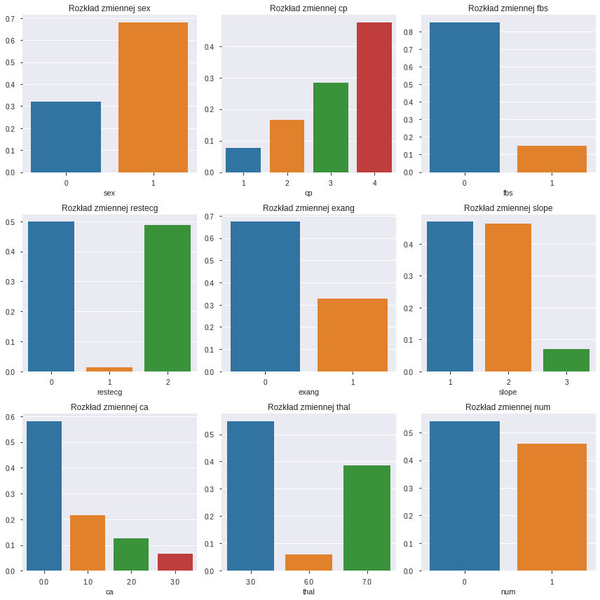

```python
f, axes=plt.subplots(3, 3, figsize=(12, 12))
variables=['sex', 'cp', 'fbs', 'restecg', 'exang', 'slope', 'ca', 'thal', 'num']
for i in range(0, len(variables)):
    sns.barplot(data=cdata, x=variables[i], y=variables[i], estimator=lambda x: len(x)/len(cdata), ax=axes[i//3, i%3]).set_title('Rozkład zmiennej '+variables[i])
for ax in f.axes:
    ax.set_ylabel('')
plt.tight_layout();
```

### Rozkłady zmiennych liczbowych

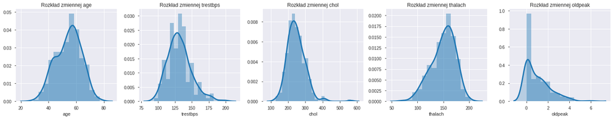

```python
f, axes = plt.subplots(1, 5, figsize=(20, 4), sharey=False)
variables=['age', 'trestbps', 'chol', 'thalach', 'oldpeak']
for i in range(0, len(variables)):
    sns.distplot(cdata[variables[i]], hist=True, kde=True, kde_kws={'shade': True, 'linewidth': 3}, ax=axes[i]).set_title('Rozkład zmiennej '+variables[i])
plt.tight_layout();
```

#### Komentarz

Rozkłady wieku, ciśnienia tętniczego i poziomu cholesterolu w serum są w dużym stopniu symetryczne. Rozkład tętna ma niedużą ujemną asymetrię, a rozkład ST depression dużą dodatnią asymetrię.

### Dygresja

Dla dosyć dużej ilości obserwacji (99 pacjentów, około 33% badanych) zmienna ST przyjmuje wartość 0 (z tego, co zrozumiałem, wynik najlepszy z medycznego punktu widzenia - https://www.ncbi.nlm.nih.gov/books/NBK459364/). W ramach eksperymentu poniżej umieszczam wykres rozkładu zmiennej ST depression z wyłączeniem wspomnianych obserwacji.

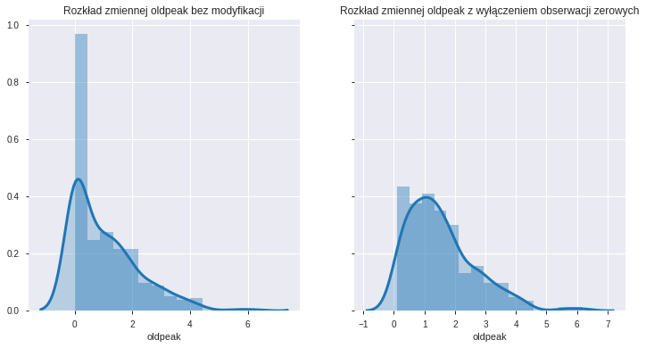

```python
f, axes = plt.subplots(1, 2, figsize=(12, 6), sharey=True)
sns.distplot(cdata.oldpeak, hist=True, kde=True, kde_kws={'shade': True, 'linewidth': 3}, ax=axes[0]).set_title('Rozkład zmiennej oldpeak bez modyfikacji')
sns.distplot(cdata.oldpeak[cdata.oldpeak!=0], hist=True, kde=True, kde_kws={'shade': True, 'linewidth': 3}, ax=axes[1]).set_title('Rozkład zmiennej oldpeak z wyłączeniem obserwacji zerowych');
```

#### Komentarz

Peak w 0 zniknął, asymetria zmniejszyła się, ale wciąż jest znaczna.

### Statystyki pozycyjne i rozproszenia zmiennych liczbowych

```python
cdata.iloc[:, [0, 3, 4, 7, 9]].describe()
```

|  | age | trestbps | chol | thalach | oldpeak |
| --- | --- | --- | --- | --- | --- |
| count | 303.000000 | 303.000000 | 303.000000 | 303.000000 | 303.000000 |
| mean | 54.438944 | 131.689769 | 246.693069 | 149.607261 | 1.039604 |
| std | 9.038662 | 17.599748 | 51.776918 | 22.875003 | 1.161075 |
| min | 29.000000 | 94.000000 | 126.000000 | 71.000000 | 0.000000 |
| 25% | 48.000000 | 120.000000 | 211.000000 | 133.500000 | 0.000000 |
| 50% | 56.000000 | 130.000000 | 241.000000 | 153.000000 | 0.800000 |
| 75% | 61.000000 | 140.000000 | 275.000000 | 166.000000 | 1.600000 |
| max | 77.000000 | 200.000000 | 564.000000 | 202.000000 | 6.200000 |

#### Komentarz

- Średni wiek badanych wynosi 54 lata, odchylenie standardowe 9, najmłodszy badany ma 29 lat, a najstarszy 77 lat,
- średnie ST depression wynosi 1.04, odchylenie standardowe 1.16 minimalne 0, a maksymalne 6.2 (https://en.wikipedia.org/wiki/ST_depression ¯\*(ツ)*/¯)

Statystyki ciśnienia tętniczego, całkowitego cholesterolu w serum i maksymalnego tętna skłoniły mnie do innej analizy, którą umieszczam poniżej:

#### Jaka część badanych przekroczyła górną normę ciśnienia tętniczego?

Norma z https://en.wikipedia.org/wiki/Blood_pressure

```python
str(round(100*cdata.loc[cdata.trestbps>=140].shape[0]/cdata.shape[0], 2)) + "%"
```

```
'32.34%'
```

#### Jaka część badanych przekroczyła górną normę całkowitego cholesterolu w serum?

Norma z https://en.wikipedia.org/wiki/Cholesterol

```python
str(round(100*cdata.loc[cdata.chol>=200].shape[0]/cdata.shape[0], 2)) + "%"
```

```
'83.83%'
```

#### Jaka część badanych przekroczyła górną normę maksymalnego tętna?

Tutaj norma zależy znacznie od wieku, dlatego posłużę się drugim wzorem "Oakland University", o rzekomo dobrej dokładności, z https://en.wikipedia.org/wiki/Heart_rate

```python
str(round(100*cdata.loc[cdata.thalach>(192-0.007*cdata.age**2)].shape[0]/cdata.shape[0], 2)) + "%"
```

```
'13.86%'
```

## Korelacje zmiennych

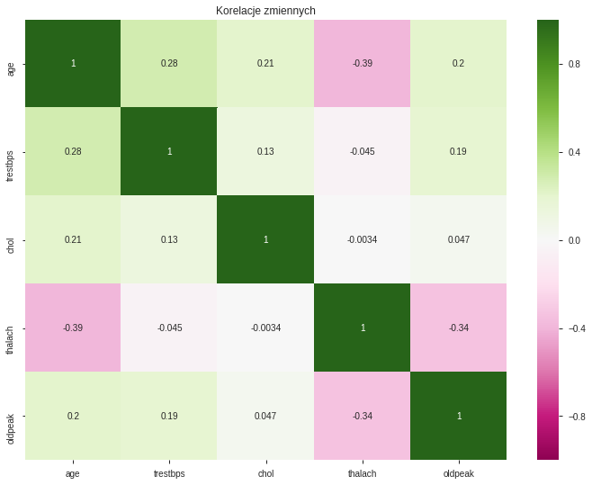

```python
corr=cdata.iloc[:, [0, 3, 4, 7, 9]].corr()
fig, ax=plt.subplots(figsize=(12,9))
ax=sns.heatmap(corr, xticklabels=corr.columns, yticklabels=corr.columns, annot=True, cmap="PiYG", center=0, vmin=-1, vmax=1)
ax.set_title('Korelacje zmiennych')
plt.show();
```

#### Komentarz

Ponieważ powyższa mapa ciepła jest dość obszerna i jednocześnie czytelna, nie będę szczegółowo opisywał zawartych na niej wyników. Niektóre z korelacji przedstawiam bardziej szczegółowo poniżej.

## Analiza wielowymiarowa

### Jak wiek wpływa na maksymalne tętno i ciśnienie tętnicze?

Poniższe wyniki pokrywają się z dostępną w internecie wiedzą, jednak jestem świadom, że 303 badanych to niewielka próba do snucia tego typu wniosków.

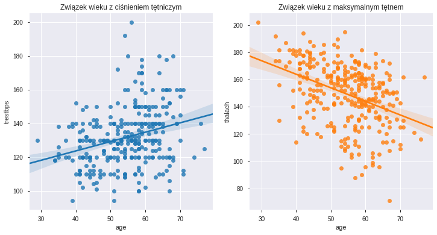

```python
f, axes = plt.subplots(1, 2, figsize=(12, 6), sharey=False)
sns.regplot(data=cdata, x='age', y='trestbps', ax=axes[0]).set_title('Związek wieku z ciśnieniem tętniczym')
sns.regplot(data=cdata, x='age', y='thalach', ax=axes[1]).set_title('Związek wieku z maksymalnym tętnem');
```

#### Komentarz

Wyższy wiek związany jest z wyższym ciśnieniem tętniczym (co ciekawe, rekordowe wartości zaobserwowano w przedziale 50-60 lat) ("In adults in most societies, systolic blood pressure tends to rise from early adulthood onward, up to at least age 70" - https://en.wikipedia.org/wiki/Blood_pressure). Wyższy wiek związany jest także z niższym maksymalnym tętnem ("The maximum heart rate is the highest heart rate an individual can achieve without severe problems through exercise stress, and generally decreases with age" - https://en.wikipedia.org/wiki/Heart_rate).

### Jakie jeszcze zmienne skorelowane są z ciśnieniem tętniczym?

```python
from scipy.stats import chi2_contingency
for i in cdata.columns:
    d=np.hstack([pd.DataFrame(cdata.trestbps),cdata[i].values.reshape(-1,1)])
    p_value=chi2_contingency(d)[1]
    if p_value<0.05:
        print('%s - POWIĄZANA' %i)
    else:
        print ('%s - NIEPOWIĄZANA' %i)
```

```
age - POWIĄZANA
sex - NIEPOWIĄZANA
cp - NIEPOWIĄZANA
trestbps - NIEPOWIĄZANA
chol - POWIĄZANA
fbs - NIEPOWIĄZANA
restecg - NIEPOWIĄZANA
thalach - POWIĄZANA
exang - NIEPOWIĄZANA
oldpeak - POWIĄZANA
slope - NIEPOWIĄZANA
ca - NIEPOWIĄZANA
thal - NIEPOWIĄZANA
num - NIEPOWIĄZANA
```

### Jaka płeć jest bardziej narażona na defekty i choroby serca?

Poniższe wyniki pokrywają się z dostępną w internecie wiedzą, jednak jestem świadom, że 303 badanych to niewielka próba do snucia tego typu wniosków.

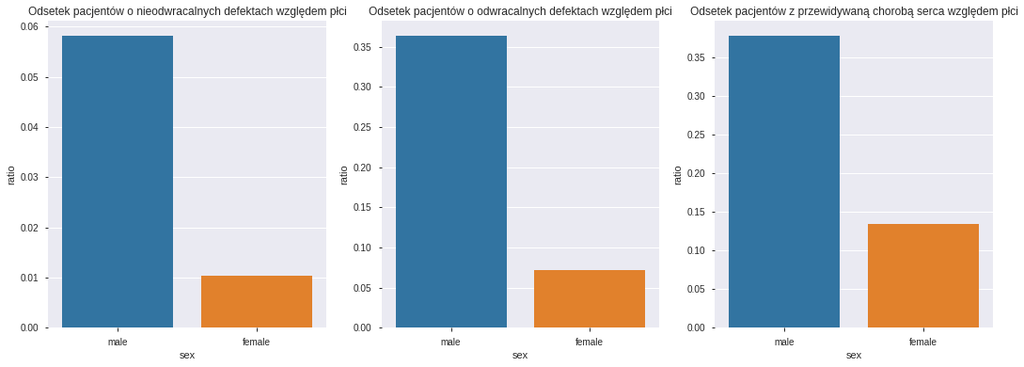

```python
# poniewaz proporcje plci w badaniu nie sa rowne policze czestosci osobno dla kazdej z nich
# uwzglednie osoby tylko z przedzialu wiekowego 40-60 (middle-age - https://en.wikipedia.org/wiki/Middle_age)
f, axes = plt.subplots(1, 3, figsize=(18, 6), sharey=False)
plotdata1=pd.DataFrame({'sex': ['male', 'female'], 'ratio': [cdata.loc[(cdata.sex==1)&(cdata.thal==6)&(cdata.age>=40)&(cdata.age<=60)].shape[0]/cdata.loc[cdata.sex==1].shape[0], cdata[(cdata.sex==0)&(cdata.thal==6)&(cdata.age>=40)&(cdata.age<=60)].shape[0]/cdata.loc[cdata.sex==0].shape[0]]})
plotdata2=pd.DataFrame({'sex': ['male', 'female'], 'ratio': [cdata.loc[(cdata.sex==1)&(cdata.thal==7)&(cdata.age>=40)&(cdata.age<=60)].shape[0]/cdata.loc[cdata.sex==1].shape[0], cdata[(cdata.sex==0)&(cdata.thal==7)&(cdata.age>=40)&(cdata.age<=60)].shape[0]/cdata.loc[cdata.sex==0].shape[0]]})
plotdata3=pd.DataFrame({'sex': ['male', 'female'], 'ratio': [cdata.loc[(cdata.sex==1)&(cdata.num==1)&(cdata.age>=40)&(cdata.age<=60)].shape[0]/cdata.loc[cdata.sex==1].shape[0], cdata[(cdata.sex==0)&(cdata.num==1)&(cdata.age>=40)&(cdata.age<=60)].shape[0]/cdata.loc[cdata.sex==0].shape[0]]})
sns.barplot(data=plotdata1, y="ratio", x="sex", ax=axes[0]).set_title('Odsetek pacjentów o nieodwracalnych defektach względem płci')
sns.barplot(data=plotdata2, y="ratio", x="sex", ax=axes[1]).set_title('Odsetek pacjentów o odwracalnych defektach względem płci')
sns.barplot(data=plotdata3, y="ratio", x="sex", ax=axes[2]).set_title('Odsetek pacjentów z przewidywaną chorobą serca względem płci');
```

#### Komentarz

Mężczyźni stanowią zdecydowaną większość badanych wśród grup o odwracalnych i nieodwracalnych defektach, a także chorobach serca ("Coronary heart diseases are 2 to 5 times more common among middle-aged men than women." - https://en.wikipedia.org/wiki/Cardiovascular_disease).

### Jaki odsetek badanych przekroczył normę całkowitego cholesterolu w serum, w danym przedziale wiekowym (z podziałem na płeć)?

Wyniki mogą być zaburzone z racji na małą próbę.

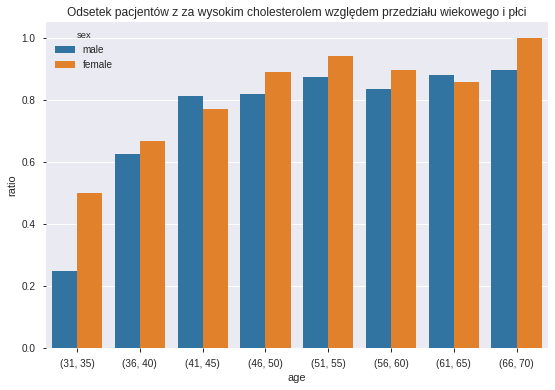

```python
# poniewaz proporcje grup wiekowych w badaniu nie sa rowne policze czestosci osobno dla kazdej z nich
# uwzglednie osoby z przedzialu wiekowego 31-70
plotdata=pd.DataFrame({'age': pd.Series([(31+5*i, 35+5*i) for i in range(0,8)]).repeat(2).reset_index(drop=True), 'sex': pd.Series(['male', 'female']*8), 'ratio': pd.Series(0).repeat(16).reset_index(drop=True)})
for i in range (0, plotdata.shape[0]):
    plotdata.iloc[i, 2]=cdata.loc[(cdata.sex==(1 if plotdata.sex[i]=='male' else 0))&(cdata.age>=plotdata.age[i][0])&(cdata.age<=plotdata.age[i][1])&(cdata.chol>=200)].shape[0]/cdata.loc[(cdata.sex==(1 if plotdata.sex[i]=='male' else 0))&(cdata.age>=plotdata.age[i][0])&(cdata.age<=plotdata.age[i][1])].shape[0]
fig, ax=plt.subplots(figsize=(9,6))
sns.barplot(data=plotdata, y='ratio', x='age', hue='sex').set_title('Odsetek pacjentów z za wysokim cholesterolem względem przedziału wiekowego i płci');
```

#### Komentarz

Odsetek badanych, którzy przekroczyli normę całkowitego cholesterolu we krwi, znacznie wzrósł przy przejściach z przedziału wiekowego 31-35 do 36-40 i z 36-40 do 41-45. W większości przedziałów wiekowych odsetek był większy dla kobiet (największa różnica wystąpiła dla przedziału wiekowego 31-35).

## Pandas-profilling

```python
profile = ProfileReport(cdata, title='Pandas Profiling Report', html={'style':{'full_width':True}})
profile.to_notebook_iframe()
```

[interactive chart not shown]

#### Komentarz

Pandas-profilling to, moim zdaniem, bardzo wygodne narzędzie do wstępnego rozeznania danych w szybki sposób. Podstawową informacją zawartą w raporcie są rozkłady, statystyki pozycyjne/rozproszenia i braki danych dotyczące poszczególnych zmiennych. Podobają mi się - opcja matrix w missing values, obrazująca położenie braków danych i informacje o zajmowanej przez zbiór pamięci. Algorytm nie zawsze poprawnie rozpoznaje typy zmiennych (np. obecność wcześniej zmodyfikowanych przeze mnie wartości -10000 powodowała rozpoznanie zmiennych kategorycznych jako ciągłe. Macierz korelacji tworzona jest dla wszystkich zmiennych, a nie zawsze tak być powinno (ponadto, duża ich ilość może spowodować nieczytelność wykresu). Raport nie pozwala na eksplorację powiązań między zmiennymi (prócz macierzy korelacji), ani na rysowanie innych typów wykresów jednowymiarowych (np. boxplot). Duża ilość przedstawianych informacji utrudnia szybkie znaleznienie tych, które nas interesują.